# p8105_hw6_jz4027

Charlotte Zhang

2025-11-27

```r
library(tidyverse)
library(broom)
library(patchwork)
library(p8105.datasets)
library(modelr)
library(mgcv)
```

# Problem 1

```r
url <- "https://raw.githubusercontent.com/washingtonpost/data-homicides/master/homicide-data.csv"
p1_df <- readr::read_csv(url, na = c("NA", ".", "")) |> janitor::clean_names()
# create city_state variable
# create a binary variable indicating whether the homicide is solved
# Omit cities
# victim_race is white or black
# victim_age is numeric

p1_df_cleaned <- p1_df |>
  mutate(city_state = paste(city, state, sep = ", ")) |>
  group_by(city_state) |>
  mutate(disposition_solved =
           ifelse(disposition == "Closed by arrest" | disposition == "Closed without arrest", 1, 0)) |>
  filter(!city_state %in% c("Dallas, TX", "Phoenix, AZ", "Kansas City, MO", "Tulsa, AL")) |>
  filter(victim_race %in% c("White", "Black")) |>
  mutate(victim_age = as.numeric(victim_age))
p1_df_cleaned
```

```
## # A tibble: 39,693 × 14
## # Groups:   city_state [47]
##    uid        reported_date victim_last  victim_first victim_race victim_age
##    <chr>              <dbl> <chr>        <chr>        <chr>            <dbl>
##  1 Alb-000003      20100601 SATTERFIELD  VIVIANA      White               15
##  2 Alb-000005      20100102 MULA         VIVIAN       White               72
##  3 Alb-000006      20100126 BOOK         GERALDINE    White               91
##  4 Alb-000009      20100130 MARTIN-LEYVA GUSTAVO      White               56
##  5 Alb-000012      20100218 LUJAN        KEVIN        White               NA
##  6 Alb-000016      20100308 GRAY         STEFANIA     White               43
##  7 Alb-000018      20100323 DAVID        LARRY        White               52
##  8 Alb-000019      20100402 BRITO        ELIZABETH    White               22
##  9 Alb-000021      20100423 KING         TEVION       Black               15
## 10 Alb-000022      20100423 BOYKIN       CEDRIC       Black               25
## # ℹ 39,683 more rows
## # ℹ 8 more variables: victim_sex <chr>, city <chr>, state <chr>, lat <dbl>,
## #   lon <dbl>, disposition <chr>, city_state <chr>, disposition_solved <dbl>
```

```r
# filter out Baltimore MD
baltimore <- p1_df_cleaned |>
  filter(city_state == "Baltimore, MD")

# logistic regression
baltimore_glm <- glm(disposition_solved ~ victim_age + victim_sex + victim_race,
                     data = baltimore,
                     family = binomial)

# tidy, and get odds ratio and CI, comparing male victims to female victims
baltimore_tidy <- broom::tidy(baltimore_glm, exponentiate = TRUE, conf.int = TRUE)

or_baltimore_sex <- baltimore_tidy |>
  filter(term == "victim_sexMale") |>
  select(term, estimate, conf.low, conf.high)
or_baltimore_sex
```

```
## # A tibble: 1 × 4
##   term           estimate conf.low conf.high
##   <chr>             <dbl>    <dbl>     <dbl>
## 1 victim_sexMale    0.355    0.267     0.468
```

```r
# Odds ratio and CI for every city
or_cities_sex <- p1_df_cleaned |>
  group_by(city_state) |>
  nest() |>
  mutate(model = map(data, ~glm(disposition_solved ~ victim_age + victim_sex + victim_race,
                                data = .,
                                family = binomial)),
         tidy_out = map(model, ~tidy(., exponentiate = TRUE, conf.int = TRUE, conf.level = 0.95))) |>
  unnest(tidy_out) |>
  filter(term == "victim_sexMale") |>
  select(city_state, estimate, conf.low, conf.high)
or_cities_sex
```

```
## # A tibble: 47 × 4
## # Groups:   city_state [47]
##    city_state      estimate conf.low conf.high
##    <chr>              <dbl>    <dbl>     <dbl>
##  1 Albuquerque, NM    0.430   0.132      1.16
##  2 Atlanta, GA        0.512   0.323      0.789
##  3 Baltimore, MD      0.355   0.267      0.468
##  4 Baton Rouge, LA    0.319   0.160      0.596
##  5 Birmingham, AL     0.704   0.444      1.09
##  6 Boston, MA         0.674   0.353      1.28
##  7 Buffalo, NY        0.438   0.239      0.793
##  8 Charlotte, NC      0.301   0.143      0.572
##  9 Chicago, IL        0.391   0.321      0.476
## 10 Cincinnati, OH     0.206   0.0977     0.390
## # ℹ 37 more rows
```

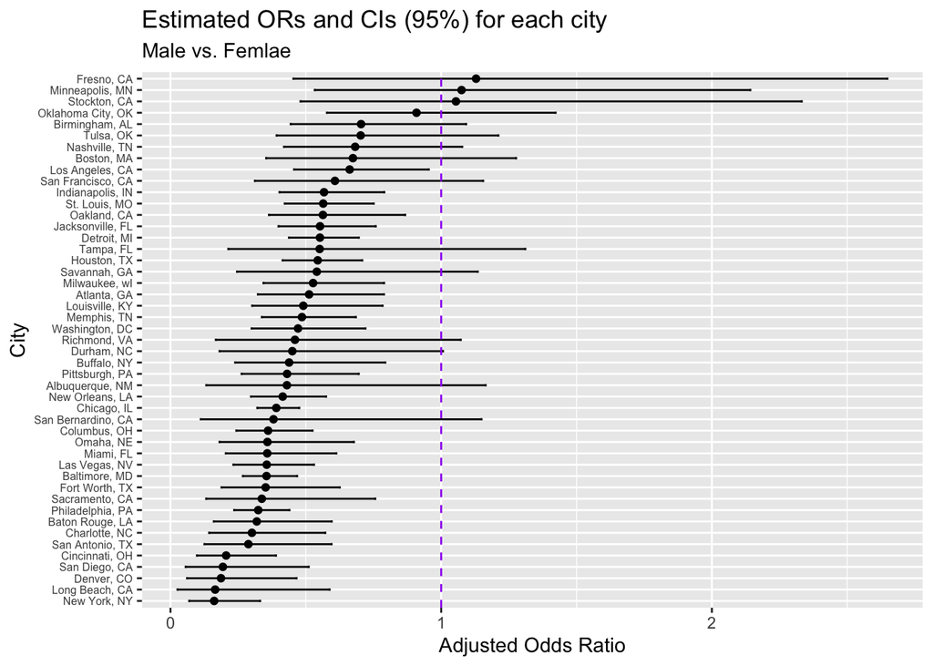

```r
or_cities_sex |>
  ggplot(aes(x = reorder(city_state, estimate), y = estimate)) +
  geom_point() +
  geom_errorbar(aes(ymin = conf.low, ymax = conf.high), width = 0.2) +
  geom_hline(yintercept = 1, linetype = "dashed", color = "purple") +
  coord_flip() +
  labs(
    title = "Estimated ORs and CIs (95%) for each city",
    subtitle = "Male vs. Femlae",
    x = "City",
    y = "Adjusted Odds Ratio"
  ) +
  theme(axis.text.y = element_text(size = 6))
```

For most cities (except for Fresno, Minneapolis, and Stockton), the estimated odds ratio is less than 1, indicating that the odds of homicides being solved are lower for male victims compared to female victims, even when factors like race and age are controlled. Then for many cities, their confidence interval is completely below 1, suggesting that the difference is not due to random chance and is statistically significant.

# Problem 2

```r
# Load the data
data("weather_df")

# bootstrap
bootstrap_stats <- weather_df |>
  modelr::bootstrap(n = 5000) |>
  mutate(
    linear_reg = map(strap, ~ lm(tmax ~ tmin + prcp, data = .x)),
    estimates = map(linear_reg, function(model) {

      coefs <- tidy(model) |>
        filter(term %in% c("tmin", "prcp")) |>
        select(term, estimate) |>
        pivot_wider(names_from = term, values_from = estimate)

      r2 <- glance(model)$r.squared

      ratio <- coefs$tmin / coefs$prcp

      tibble(r_squared = r2, beta_ratio = ratio)
    })
  ) |>
  unnest(estimates) |>
  select(-strap, -linear_reg)

bootstrap_stats
```

```
## # A tibble: 5,000 × 3
##    .id   r_squared beta_ratio
##    <chr>     <dbl>      <dbl>
##  1 0001      0.941      -204.
##  2 0002      0.938      -195.
##  3 0003      0.945      -198.
##  4 0004      0.946      -170.
##  5 0005      0.942      -202.
##  6 0006      0.945      -203.
##  7 0007      0.945      -183.
##  8 0008      0.945      -193.
##  9 0009      0.946      -173.
## 10 0010      0.942      -254.
## # ℹ 4,990 more rows
```

```r
# CI
ci_r2 <- quantile(bootstrap_stats$r_squared, c(0.025, 0.975))
ci_ratio <- quantile(bootstrap_stats$beta_ratio, c(0.025, 0.975))
```

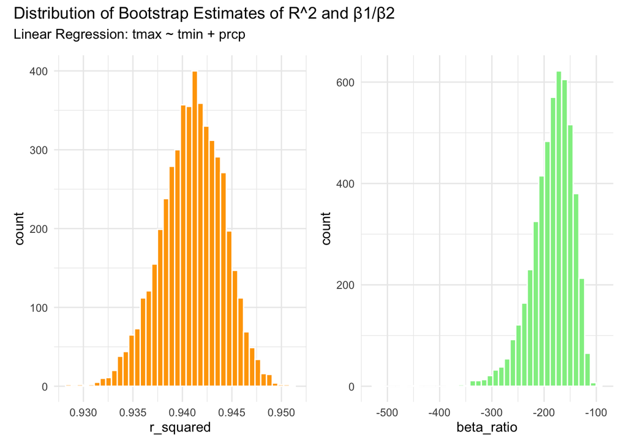

```r
# plot
r2_plot <- ggplot(bootstrap_stats, aes(x = r_squared)) +
  geom_histogram(bins = 40, fill = "orange", color = "white") +
  theme_minimal()

beta_plot <- ggplot(bootstrap_stats, aes(x = beta_ratio)) +
  geom_histogram(bins = 40, fill = "lightgreen", color = "white") +
  theme_minimal()

(r2_plot | beta_plot) +
  plot_annotation(
    title = "Distribution of Bootstrap Estimates of R^2 and β1/β2",
    subtitle = "Linear Regression: tmax ~ tmin + prcp"
  )
```

- The 95% confidence interval for r-squared is 0.9345088, 0.9467165, which is pretty narrow. The distribution is approximately symmetric, bell-shaped, and centered around 0.941. This shows that the simple linear regression model provides consistent and stable r^2 (proportion of variance explained in tmax) of the bootstrapped datasets, tmin + prcp are reliable predictors of tmax.
- The 95% confidence interval for beta ratio is -277.8746405, -125.6924754. The CI is wider, negative, and the distribution is centered around -170, highly skewed to the left. This suggest that the estimated beta ratio is unstable because beta2 (precipitation) is noisy and small.

# Problem 3

```r
# Load and clean the data
p3_data <- read_csv("birthweight.csv") |>
  janitor::clean_names() |>
  mutate(
    babysex = factor(babysex, levels = c(1,2), labels = c("Male", "Female")),
    frace = factor(frace, levels = c(1,2,3,4,8,9),
                   labels = c("White", "Black", "Asian", "Puerto Rican", "Other", "Unknown")),
    mrace = factor(mrace, levels = c(1,2,3,4,8),
                   labels = c("White", "Black", "Asian", "Puerto Rican", "Other")),
    malform = factor(malform, levels = c(0,1), labels = c("Absent", "Present")),
    across(-c(babysex, frace, mrace, malform), as.numeric)
  )
colSums(is.na(p3_data))
```

```
##  babysex    bhead  blength      bwt    delwt  fincome    frace  gaweeks
##        0        0        0        0        0        0        0        0
##  malform menarche  mheight   momage    mrace   parity  pnumlbw  pnumsga
##        0        0        0        0        0        0        0        0
##    ppbmi     ppwt   smoken   wtgain
##        0        0        0        0
```

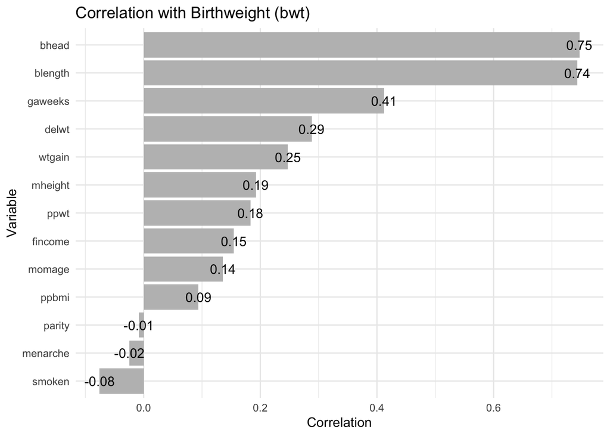

```r
# check correlation
p3_data_num <- p3_data |> select(where(is.numeric)) |>
  select(where(~ any(.x != 0)))

cor_with_bwt <- cor(p3_data_num, use = "complete.obs")[, "bwt"]
cor_with_bwt <- cor_with_bwt[names(cor_with_bwt) != "bwt"]

cor_table <- tibble(
  variable = names(cor_with_bwt),
  correlation = cor_with_bwt
)

ggplot(cor_table, aes(x = reorder(variable, correlation), y = correlation)) +
  geom_col(fill = "grey") +
  coord_flip() +
  geom_text(
    aes(label = round(correlation, 2))) +
  labs(title = "Correlation with Birthweight (bwt)",
       x = "Variable",
       y = "Correlation") +
  theme_minimal()
```

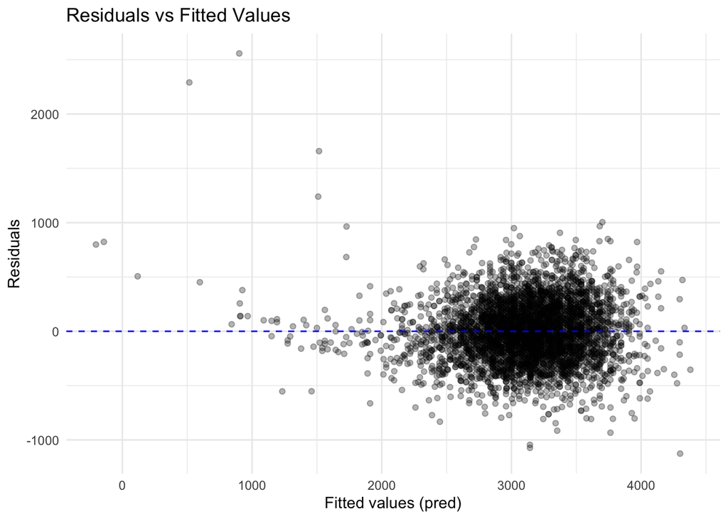

```r
p3_model1 <- lm(bwt ~ bhead + blength + babysex + frace + mrace + malform,
             data = p3_data)

p3_data |>
  add_predictions(p3_model1, var = "pred") |>
  add_residuals(p3_model1, var = "resid") |>
  ggplot(aes(x = pred, y = resid)) +
  geom_point(alpha = 0.3) +
  geom_hline(yintercept = 0, color = "blue", linetype = "dashed") +
  labs(x = "Fitted values (pred)", y = "Residuals",
       title = "Residuals vs Fitted Values") +
  theme_minimal()
```

For this regression model, I checked the correlation between birth weight and other numerical variables, and included the two with the highest correlation in model1. I also included all categorical variables, like babysex, frace, mrace, and malform, in model1 because these factors are commonly hypothesized to affect birthweight. Looking at the plot, residuals for larger fitted values are centered around 0 and clustered, while residuals for small fitted values are more spread with some outliers. Overall, the linear regression model predicts birthweight reasonably well

```r
# cross validation
cv_df <- crossv_mc(p3_data, 100) |>
  mutate(
    train = map(train, as_tibble),
    test  = map(test, as_tibble)
  )

cv_df <- cv_df |>
  mutate(
    p3_model1 = map(train, \(df) lm(bwt ~ bhead + blength + babysex + frace + mrace + malform, data = df)),
    p3_model2 = map(train, \(df) lm(bwt ~ blength + gaweeks, data = df)),
    p3_model3 = map(train, \(df) lm(bwt ~ (bhead + blength + babysex)^3, data = df))
  ) |>
  mutate(
    rmse_model1 = map2_dbl(p3_model1, test, \(mod, df) rmse(model = mod, data = df)),
    rmse_model2 = map2_dbl(p3_model2, test, \(mod, df) rmse(model = mod, data = df)),
    rmse_model3 = map2_dbl(p3_model3, test, \(mod, df) rmse(model = mod, data = df)))
```

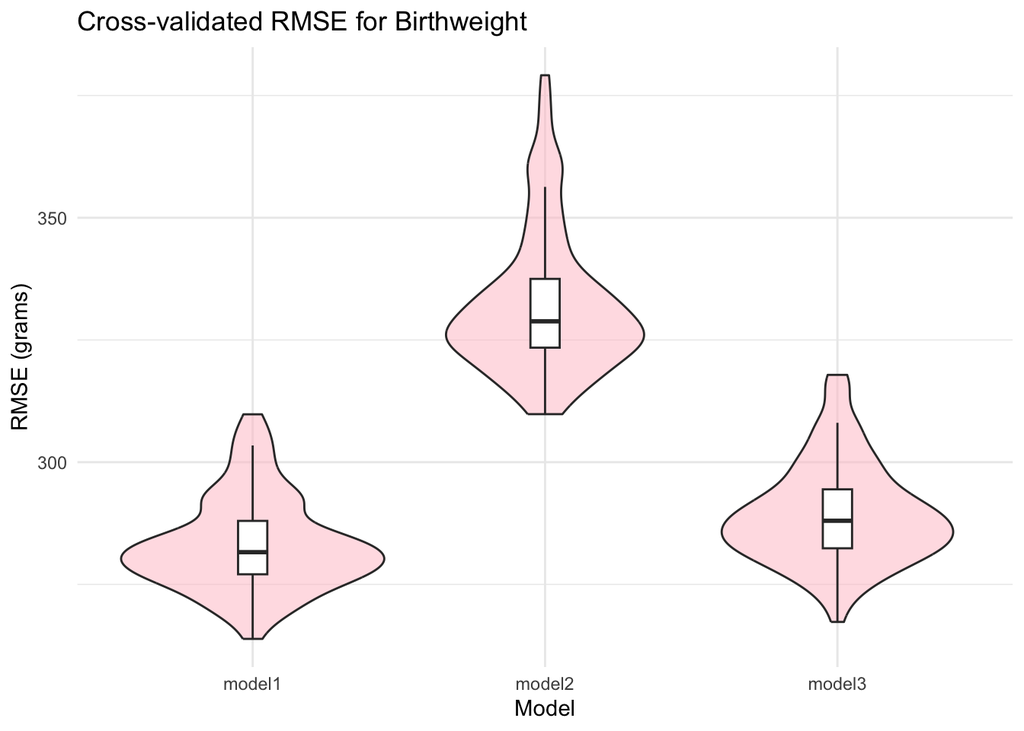

```r
# plot
cv_df |>
  select(starts_with("rmse")) |>
  pivot_longer(
    everything(),
    names_to = "model",
    values_to = "rmse",
    names_prefix = "rmse_"
  ) |>
  mutate(model = fct_inorder(model)) |>
  ggplot(aes(x = model, y = rmse)) +
  geom_violin(fill = "pink", alpha = 0.5) +
  geom_boxplot(width = 0.1, outlier.shape = NA) +
  labs(title = "Cross-validated RMSE for Birthweight",
       x = "Model",
       y = "RMSE (grams)") +
  theme_minimal()
```

My model (model 1) performs the best because its median rmse is approximately 280, which is smaller than model 2’s rmse of 330 and the model 3’s rmse of 285-290. Also, model 1 has the smallest spread among the three, suggesting a better stability. Model 2 has the worst performance overall.